# Social Determinants of Health

**Analysis by Tamar Kellner**

The conditions under which someone grows up and lives under greatly impact their quality of life, especially when it comes to health. According to the CDC, "Social determinants of health (SDOH) are conditions in the places where people live, learn, work, and play that affect a wide range of health risks and outcomes." While this is recognizable, it can be hard to identify which determinants to focus on improving. While all are important, there are not endless resources available to help improve the health of the population. This project aims to identify how impactful different demographic features can be on health outcomes.

To learn more about social determinants of health and goals surrounding this issue, visit the US Department of Health and Human Services' Healthy People 2030 initiative: https://health.gov/healthypeople/priority-areas/social-determinants-health

### 1. Data Collection

To analyze different social determinants of health in the United States, this tutorial will use data from the CDC's 2020 Behavioral Risk Factor Surveillance System Survey. The goal of this survey is to "Collect uniform state-specific data on health risk behaviors, chronic diseases and conditions, access to health care, and use of preventive health services related to the leading causes of death and disability in the United States." The dataset is available from the CDC in ASCII format, however it was also made available as a csv file on Kaggle.com. This tutorial will use the csv version, so we will need to load the dataset in using the Kaggle API.

To learn more about the survey, including how it was conducted and what data is available, navigate to: https://www.cdc.gov/brfss/annual_data/annual_2020.html

In order to load the dataset, you must first create an API access token on Kaggle. Do this with the following steps:

1. Go to kaggle.com and log in (or create a free account if you don't already have one)
2. Navigate to your profile in the upper righthand corner of the website
3. Go to the account tab and scroll down to where it says API. Click on 'Create New API Token', and a kaggle.json file will automatically download to your computer

Next, use the following commands to install the Kaggle library, upload the kaggle.json file from the above step, and then download the specific csv file that will be used in this tutorial.

```python
# install the Kaggle library
%pip install -q kaggle

# use the files library to upload the kaggle.json file that is on your local computer
from google.colab import files
upload = files.upload()
```

Upload widget is only available when the cell has been executed in the current browser session. Please rerun this cell to enable.

```
Saving kaggle.json to kaggle.json
```

```python
# store the kaggle.json file in a new directory called kaggle
! mkdir ~/.kaggle
! cp kaggle.json ~/.kaggle/

# allocate permissions for the kaggle.json file
! chmod 600 ~/.kaggle/kaggle.json

# download the specific dataset that will be used in this project and unzip the file in a new directory called survey-data
! kaggle datasets download -d aemreusta/brfss-2020-survey-data
! mkdir survey-data
! unzip brfss-2020-survey-data.zip -d survey-data
```

```
mkdir: cannot create directory ‘/root/.kaggle’: File exists
Downloading brfss-2020-survey-data.zip to /content
 79% 38.0M/48.3M [00:00<00:00, 109MB/s]
100% 48.3M/48.3M [00:00<00:00, 109MB/s]
Archive:  brfss-2020-survey-data.zip
  inflating: survey-data/brfss2020.csv
```

```python
# import all libraries that will be needed for this tutorial
import pandas as pd
import numpy as np
import matplotlib
import matplotlib.pyplot as plt
import statsmodels.api as sm
```

```python
# read the csv file into a Pandas dataframe
survey = pd.read_csv('survey-data/brfss2020.csv')
survey.head()
```

|  | _STATE | FMONTH | IDATE | IMONTH | IDAY | IYEAR | DISPCODE | SEQNO | _PSU | CTELENM1 | ... | _RFPSA23 | _CLNSCPY | _SGMSCPY | _SGMS10Y | _RFBLDS4 | _STOLDNA | _VIRCOLN | _SBONTIM | _CRCREC1 | _AIDTST4 |
| --- | --- | --- | --- | --- | --- | --- | --- | --- | --- | --- | --- | --- | --- | --- | --- | --- | --- | --- | --- | --- | --- |
| 0 | 1.0 | 1.0 | 1042020 | 1 | 4 | 2020 | 1100.0 | 2020000001 | 2.020000e+09 | 1.0 | ... | NaN | 1.0 | 3.0 | 3.0 | 3.0 | 3.0 | 3.0 | 3.0 | 1.0 | 1.0 |
| 1 | 1.0 | 1.0 | 2072020 | 2 | 7 | 2020 | 1200.0 | 2020000002 | 2.020000e+09 | 1.0 | ... | NaN | NaN | NaN | NaN | NaN | NaN | NaN | 2.0 | NaN | NaN |
| 2 | 1.0 | 1.0 | 1232020 | 1 | 23 | 2020 | 1100.0 | 2020000003 | 2.020000e+09 | 1.0 | ... | NaN | 1.0 | 3.0 | 3.0 | 3.0 | 3.0 | 3.0 | 3.0 | 1.0 | 2.0 |
| 3 | 1.0 | 1.0 | 1092020 | 1 | 9 | 2020 | 1100.0 | 2020000004 | 2.020000e+09 | 1.0 | ... | NaN | NaN | NaN | NaN | NaN | NaN | NaN | NaN | NaN | 2.0 |
| 4 | 1.0 | 1.0 | 1042020 | 1 | 4 | 2020 | 1100.0 | 2020000005 | 2.020000e+09 | 1.0 | ... | NaN | NaN | NaN | NaN | NaN | NaN | NaN | NaN | NaN | 9.0 |

5 rows × 279 columns

### 2. Data Tidying

Data tidying is a key step in the data science pipeline as it creates cleaner and more readable data to produce the highest quality results. Spending time to tidy data can be tedious, but it will allow for better productivity during analysis.

To learn more about tidying data in python, read here: https://medium.com/analytics-vidhya/tidying-data-in-python-78e48eb0bdfd

Out of 401,958 individuals surveyed, 330,619 completed the entire interview, while 71,339 had incomplete interviews. In order to have complete data on all participants being evaluated in this project we will only include the completed interviews in this analysis.

```python
# Locate all rows that represent complete interviews (final disposition code = 1100)
survey = survey.loc[(survey['DISPCODE'] == 1100)]

# Create a dataframe that only contains the attributes relevant to this analysis.
survey_df = survey[['SEXVAR', '_EDUCAG', 'VETERAN3', 'EMPLOY1', '_INCOMG', '_IMPRACE', '_AGE65YR', 'PHYSHLTH', 'MENTHLTH', 'HLTHPLN1', 'CVDINFR4', 'CVDCRHD4', 'CVDSTRK3', 'ASTHMA3', 'CHCSCNCR', 'CHCOCNCR', 'CHCCOPD2', 'HAVARTH4', 'ADDEPEV3', 'CHCKDNY2', 'DIABETE4']]

# The following is dictionary of column names and what to rename them to. Pass this as an argument to Pandas' rename method to make column names more readable.
new_col_names = {"SEXVAR": "Sex",
                 "_EDUCAG": "Education",
                 "VETERAN3": "Veteran",
                 "EMPLOY1": "Employment_Status",
                 "_INCOMG": "Income_Group",
                 "_IMPRACE": "Race",
                 "_AGE65YR": "Age",
                 "PHYSHLTH": "Physical_Health",
                 "MENTHLTH": "Mental_Health",
                 "HLTHPLN1": "Healthcare_Coverage",
                 "CVDINFR4": "Heart_Attack",
                 "CVDCRHD4": "Angina_HeartDisease",
                 "CVDSTRK3": "Stroke",
                 "ASTHMA3": "Asthma",
                 "CHCSCNCR": "Skin_Cancer",
                 "CHCOCNCR": "Other_Cancer",
                 "CHCCOPD2": "COPD",
                 "HAVARTH4": "Arthritis",
                 "ADDEPEV3": "Depression",
                 "CHCKDNY2": "Kidney_Disease",
                 "DIABETE4": "Diabetes"}

survey_df = survey_df.rename(columns = new_col_names)

survey_df.head()
```

|  | Sex | Education | Veteran | Employment_Status | Income_Group | Race | Age | Physical_Health | Mental_Health | Healthcare_Coverage | ... | Angina_HeartDisease | Stroke | Asthma | Skin_Cancer | Other_Cancer | COPD | Arthritis | Depression | Kidney_Disease | Diabetes |
| --- | --- | --- | --- | --- | --- | --- | --- | --- | --- | --- | --- | --- | --- | --- | --- | --- | --- | --- | --- | --- | --- |
| 0 | 2.0 | 4.0 | 2.0 | 4.0 | 1.0 | 1.0 | 1.0 | 3.0 | 30.0 | 2.0 | ... | 2.0 | 2.0 | 1.0 | 1.0 | 1.0 | 1.0 | 1.0 | 1.0 | 2.0 | 1.0 |
| 2 | 2.0 | 3.0 | 2.0 | 7.0 | 5.0 | 2.0 | 2.0 | 88.0 | 88.0 | 1.0 | ... | 2.0 | 2.0 | 2.0 | 2.0 | 1.0 | 2.0 | 1.0 | 2.0 | 2.0 | 3.0 |
| 3 | 2.0 | 2.0 | 2.0 | 5.0 | 9.0 | 1.0 | 2.0 | 88.0 | 88.0 | 1.0 | ... | 2.0 | 2.0 | 2.0 | 2.0 | 2.0 | 2.0 | 2.0 | 2.0 | 2.0 | 3.0 |
| 4 | 2.0 | 4.0 | 2.0 | 7.0 | 9.0 | 1.0 | 2.0 | 88.0 | 88.0 | 1.0 | ... | 2.0 | 1.0 | 2.0 | 2.0 | 2.0 | 2.0 | 2.0 | 2.0 | 2.0 | 3.0 |
| 5 | 1.0 | 2.0 | 2.0 | 8.0 | 3.0 | 1.0 | 2.0 | 20.0 | 30.0 | 1.0 | ... | 2.0 | 2.0 | 1.0 | 2.0 | 2.0 | 1.0 | 1.0 | 2.0 | 2.0 | 1.0 |

5 rows × 21 columns

Drop the rows that have any null values. There are very few nulls in this dataframe, so this should not skew the data much.

```python
# Count how many null values there are in each column
survey_df.isnull().sum()
```

```
Sex                    0
Education              0
Veteran                0
Employment_Status      0
Income_Group           0
Race                   0
Age                    0
Physical_Health        2
Mental_Health          2
Healthcare_Coverage    0
Heart_Attack           3
Angina_HeartDisease    0
Stroke                 0
Asthma                 0
Skin_Cancer            0
Other_Cancer           0
COPD                   0
Arthritis              0
Depression             0
Kidney_Disease         0
Diabetes               0
dtype: int64
```

```python
# drop the rows with null values
survey_df.dropna(inplace = True)
```

Many of the columns in this dataset have some responses of "Don’t know/Not Sure" or "Refused." We will drop those rows so that we have definitive values for all data points. While this shrinks the dataset we are working with, we will be able to analyze all features if we make sure that all questions are answered.

```python
survey_df = survey_df.loc[(survey_df['Education'] != 9) &
                          (survey_df['Veteran'] != 9) & (survey_df['Veteran'] != 7) &
                          (survey_df['Employment_Status'] != 9) &
                          (survey_df['Income_Group'] != 9) &
                          (survey_df['Age'] != 3) &
                          (survey_df['Physical_Health'] != 99) & (survey_df['Physical_Health'] != 77) &
                          (survey_df['Mental_Health'] != 99) & (survey_df['Mental_Health'] != 77) &
                          (survey_df['Healthcare_Coverage'] != 9) & (survey_df['Healthcare_Coverage'] != 7) &
                          (survey_df['Heart_Attack'] != 9) & (survey_df['Heart_Attack'] != 7) &
                          (survey_df['Angina_HeartDisease'] != 9) & (survey_df['Angina_HeartDisease'] != 7) &
                          (survey_df['Stroke'] != 9) & (survey_df['Stroke'] != 7) &
                          (survey_df['Asthma'] != 9) & (survey_df['Asthma'] != 7) &
                          (survey_df['Skin_Cancer'] != 9) & (survey_df['Skin_Cancer'] != 7) &
                          (survey_df['Other_Cancer'] != 9) & (survey_df['Other_Cancer'] != 7) &
                          (survey_df['COPD'] != 9) & (survey_df['COPD'] != 7) &
                          (survey_df['Arthritis'] != 9) & (survey_df['Arthritis'] != 7) &
                          (survey_df['Depression'] != 9) & (survey_df['Depression'] != 7) &
                          (survey_df['Kidney_Disease'] != 9) & (survey_df['Kidney_Disease'] != 7) &
                          (survey_df['Diabetes'] != 9) & (survey_df['Diabetes'] != 7)]
```

```python
# The answer code for having no days of poor mental or physical health is 88. Convert any instances of this to 0 to represent 0 days.
survey_df['Physical_Health'] = np.where(survey_df['Physical_Health'] == 88, 0, survey_df['Physical_Health'])
survey_df['Mental_Health'] = np.where(survey_df['Mental_Health'] == 88, 0, survey_df['Mental_Health'])
```

One important aspect of community health is chronic illness. According to the American Public Health Association, chronic diseases are the leading cause of death and disability in the U.S. and among the most costly and preventable.

For more information on the economics of chronic disease, read here: https://www.apha.org/~/media/files/pdf/factsheets/chronicdiseasefact_final.ashx

Eleven of the columns in our table are chronic illnesses, so we will use them in our analysis of population health:

- Heart Attack
- Angina or Coronary Heart Disease
- Stroke
- Asthma
- Skin Cancer
- Other Cancer
- COPD
- Arthritis
- Depression
- Kidney Disease
- Diabetes

In order to utilize chronic health as a whole, add a column to the table that tracks how many chronic illnesses each respondent reports having.

```python
chronic_diseases = ['Heart_Attack', 'Angina_HeartDisease', 'Stroke', 'Asthma', 'Skin_Cancer', 'Other_Cancer', 'COPD', 'Arthritis', 'Depression', 'Kidney_Disease', 'Diabetes']

# Given a row of the dataframe, sum up how many of the chronic diseases in the above list the respondent has been diagnoseed with.
def sum_cd(row):
    diseases = 0

    for cd in chronic_diseases:
      # The Diabetes column has a 1 for yes and a 2 for yes but only diagnosed during pregnancy, so we will include both as cases. All other chronic diseases are only positive with a value of 1
      if cd == 'Diabetes':
        positives = [1,2]
      else:
        positives = [1]

      if row[cd] in positives:
        diseases += 1

    return diseases

survey_df['num_chronic_diseases'] = survey_df.apply(lambda row: sum_cd(row), axis=1)
```

We now have an organized and clean data table to use in our analysis.

```python
survey_df.head()
```

|  | Sex | Education | Veteran | Employment_Status | Income_Group | Race | Age | Physical_Health | Mental_Health | Healthcare_Coverage | ... | Stroke | Asthma | Skin_Cancer | Other_Cancer | COPD | Arthritis | Depression | Kidney_Disease | Diabetes | num_chronic_diseases |
| --- | --- | --- | --- | --- | --- | --- | --- | --- | --- | --- | --- | --- | --- | --- | --- | --- | --- | --- | --- | --- | --- |
| 0 | 2.0 | 4.0 | 2.0 | 4.0 | 1.0 | 1.0 | 1.0 | 3.0 | 30.0 | 2.0 | ... | 2.0 | 1.0 | 1.0 | 1.0 | 1.0 | 1.0 | 1.0 | 2.0 | 1.0 | 7 |
| 2 | 2.0 | 3.0 | 2.0 | 7.0 | 5.0 | 2.0 | 2.0 | 0.0 | 0.0 | 1.0 | ... | 2.0 | 2.0 | 2.0 | 1.0 | 2.0 | 1.0 | 2.0 | 2.0 | 3.0 | 2 |
| 5 | 1.0 | 2.0 | 2.0 | 8.0 | 3.0 | 1.0 | 2.0 | 20.0 | 30.0 | 1.0 | ... | 2.0 | 1.0 | 2.0 | 2.0 | 1.0 | 1.0 | 2.0 | 2.0 | 1.0 | 4 |
| 8 | 2.0 | 4.0 | 2.0 | 1.0 | 4.0 | 1.0 | 1.0 | 28.0 | 0.0 | 1.0 | ... | 2.0 | 2.0 | 2.0 | 2.0 | 2.0 | 2.0 | 2.0 | 2.0 | 3.0 | 0 |
| 10 | 2.0 | 4.0 | 2.0 | 7.0 | 5.0 | 1.0 | 2.0 | 15.0 | 0.0 | 1.0 | ... | 2.0 | 1.0 | 1.0 | 2.0 | 2.0 | 2.0 | 2.0 | 2.0 | 3.0 | 2 |

5 rows × 22 columns

### 3. Exploratory Data Analysis

Now that our data is cleaned and readable, we can begin to analyze trends in the data. First, let's look at how chronic diseases impact both mental and physical health.

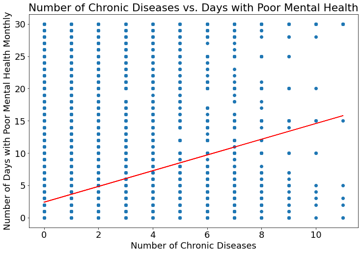

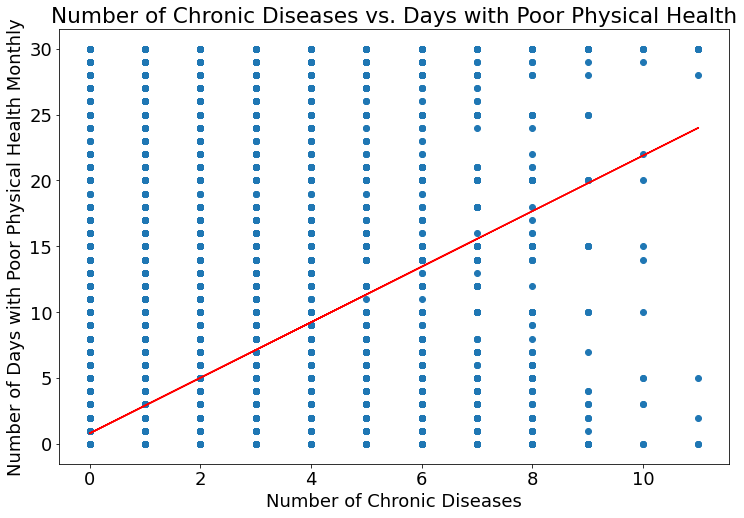

```python
# set default font for matplotlib graphs
font = {'size'   : 18}
matplotlib.rc('font', **font)

# Plot the number of chronic illnesses vs days with poor physical health for each respondent and create a regression line using
# numpy's polyfit function


for health in ['Mental_Health', 'Physical_Health']:
  plt.figure(figsize=(12,8))
  plt.title('Number of Chronic Diseases vs. Days with Poor ' + health.split('_')[0] + ' Health')
  plt.xlabel('Number of Chronic Diseases')
  plt.ylabel('Number of Days with Poor ' + health.split('_')[0] + ' Health Monthly')

  x = survey_df.num_chronic_diseases
  y = survey_df[health]

  # regression line
  fit_line = np.polyfit(x, y, deg=1)

  plt.plot(x, fit_line[0] * x + fit_line[1], color='red')
  plt.scatter(x, y)

  plt.show()
```

The above scatter plots demonstrate a positive correlation between the number of chronic diseases someone has and the number of days they consider to be in poor mental and physical health. The regression lines demonstrate that the number of chronic diseases someone has are a good indicator for health as a whole as they are both positive correlations.

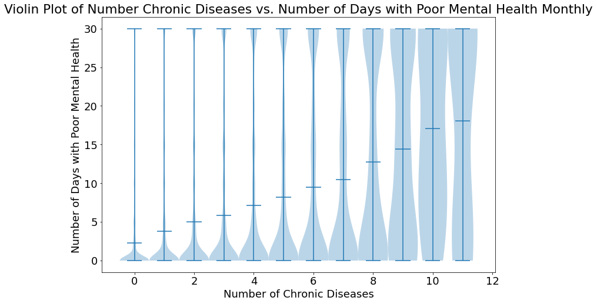

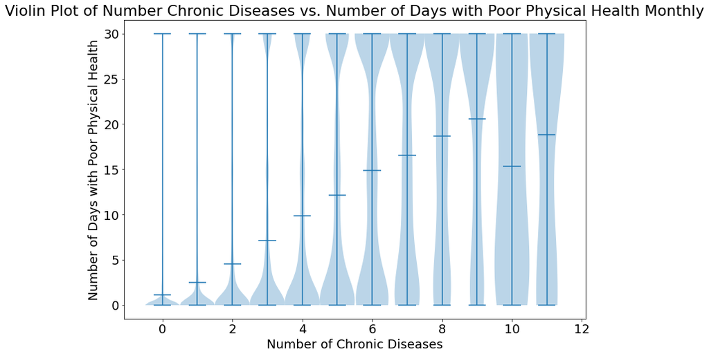

```python
# Iterate through range of number of chronic diseases and create a list of number of poor physical and mental health days for each. Use those lists to create a violin plots.

for health in ['Mental_Health', 'Physical_Health']:
  violin_plt = []
  num_cds = list(range(0, 12))
  for i in num_cds:
      temp = survey_df.loc[survey_df['num_chronic_diseases'] == i]
      num_days_list = temp[health].values
      violin_plt.append(num_days_list)


  fig, ax = plt.subplots(figsize=(12, 8))


  ax.violinplot(violin_plt, num_cds, widths=1, showmeans=True)
  ax.set_xlabel('Number of Chronic Diseases')
  ax.set_ylabel('Number of Days with Poor ' + health.split('_')[0] + ' Health')
  ax.set_title('Violin Plot of Number Chronic Diseases vs. Number of Days with Poor ' + health.split('_')[0] + ' Health Monthly')

  fig.show()
```

As the number of chronic diseases increases, the distributions of days with poor mental and physical health go from being concentrated on the bottom to concentrated on the top and then to a more equal distribution. Many of the distributions are bi-modal, which could allude to an all-or-nothing mindset of respondents when talking about their health. Many either think of their health as pretty good most of the time or pretty bad most of the time, and it is only once we get to distributions for people with the highest number of chronic illnesses that we see more even distributions. This could possibly be because people with more diseases may actually be tracking their health more closely out of need. On the lower end of chronic diseases, there are some outliers that skew the distributions. In both of these violin plots we can look at the mean markers to see what was shown with the regression line on the scatter plots - as the number of chronic diseases someone has increases, both their physical and mental health deteriorate.

### 4. OLS Model

In order to determine which demographic features are the best indicators for number of chronic diseases, we can make an Ordinary Least Squares (OLS) Regression Model.

To learn more about statsmodels' OLS model, read the documentation here: https://www.statsmodels.org/dev/generated/statsmodels.regression.linear_model.OLS.html

We will use the following demographic features as the independent variables for our model:

- Healthcare Coverage
- Race
- Annual Household Income Bracket
- Age (under or over 65)
- Employment Status
- Education Level
- Sex (M/F)
- Veteran Status

```python
demographics = survey_df[['Healthcare_Coverage', 'Race', 'Income_Group', 'Age', 'Employment_Status', 'Education', 'Sex', 'Veteran']]

# Create dummy variables for each of the following columns. Set drop_first to True to eliminate duplicate dependencies.
dummies = pd.get_dummies(demographics, columns=['Race', 'Income_Group', 'Age', 'Employment_Status', 'Education', 'Sex', 'Veteran'], drop_first=True)

vars = dummies
vars['chronic_diseases'] = survey_df['num_chronic_diseases']
```

```python
x = vars.iloc[:, :-1]
y = vars['chronic_diseases']
LinearModel = sm.OLS(y, x).fit()
print(LinearModel.summary())
```

```
                                 OLS Regression Results
=======================================================================================
Dep. Variable:       chronic_diseases   R-squared (uncentered):                   0.548
Model:                            OLS   Adj. R-squared (uncentered):              0.548
Method:                 Least Squares   F-statistic:                          1.339e+04
Date:                Mon, 16 May 2022   Prob (F-statistic):                        0.00
Time:                        19:12:31   Log-Likelihood:                     -4.1759e+05
No. Observations:              254298   AIC:                                  8.352e+05
Df Residuals:                  254275   BIC:                                  8.355e+05
Df Model:                          23
Covariance Type:            nonrobust
=========================================================================================
                            coef    std err          t      P>|t|      [0.025      0.975]
-----------------------------------------------------------------------------------------
Healthcare_Coverage       0.2403      0.008     30.285      0.000       0.225       0.256
Race_2.0                 -0.1379      0.010    -14.006      0.000      -0.157      -0.119
Race_3.0                 -0.3706      0.017    -22.319      0.000      -0.403      -0.338
Race_4.0                  0.0777      0.020      3.965      0.000       0.039       0.116
Race_5.0                 -0.2241      0.009    -24.099      0.000      -0.242      -0.206
Race_6.0                  0.0488      0.014      3.527      0.000       0.022       0.076
Income_Group_2.0          0.2263      0.011     21.382      0.000       0.206       0.247
Income_Group_3.0          0.1574      0.012     13.359      0.000       0.134       0.181
Income_Group_4.0          0.0803      0.011      7.235      0.000       0.059       0.102
Income_Group_5.0         -0.0141      0.010     -1.436      0.151      -0.033       0.005
Age_2.0                   0.5921      0.008     77.799      0.000       0.577       0.607
Employment_Status_2.0     0.0516      0.009      5.650      0.000       0.034       0.070
Employment_Status_3.0     0.5747      0.020     28.653      0.000       0.535       0.614
Employment_Status_4.0     0.2167      0.013     16.322      0.000       0.191       0.243
Employment_Status_5.0     0.2185      0.013     16.316      0.000       0.192       0.245
Employment_Status_6.0    -0.1391      0.017     -8.112      0.000      -0.173      -0.105
Employment_Status_7.0     0.5742      0.008     68.178      0.000       0.558       0.591
Employment_Status_8.0     1.8935      0.011    165.932      0.000       1.871       1.916
Education_2.0             0.3633      0.011     34.558      0.000       0.343       0.384
Education_3.0             0.4597      0.011     43.404      0.000       0.439       0.480
Education_4.0             0.3347      0.011     31.290      0.000       0.314       0.356
Sex_2.0                   0.1904      0.005     35.026      0.000       0.180       0.201
Veteran_2.0              -0.0432      0.008     -5.624      0.000      -0.058      -0.028
==============================================================================
Omnibus:                    52078.381   Durbin-Watson:                   1.986
Prob(Omnibus):                  0.000   Jarque-Bera (JB):           119771.264
Skew:                           1.166   Prob(JB):                         0.00
Kurtosis:                       5.423   Cond. No.                         16.4
==============================================================================

Warnings:
[1] Standard Errors assume that the covariance matrix of the errors is correctly specified.
```

The P-value for every demographic feature used is below the alpha value of 0.05 except for that of the largest income bracket. Thus, the rest of the features are statistically significant for determining number of chronic diseases.

Some of these, especially employment status, may actually be a reverse correlation. Being unable to work is more likely a result of chronic disease, and therefor is not a factor that can be improved upon in order to decrease risk of chronic disease. The variables that can be focused on, however, are age, employment unrelated to ability to work, access to education, and racial inequities.

### 5. Access to Healthcare

We now know that education level is a significant factor in determining health outcomes. If people with lower levels of education are predisposed to have worse health, they are probably in greater need of healthcare more often. Let's explore what the distribution of healthcare coverage is like for respondents based on their education level.

```
[Text(0, 0, 'No Coverage'), Text(0, 0, 'Coverage')]
```

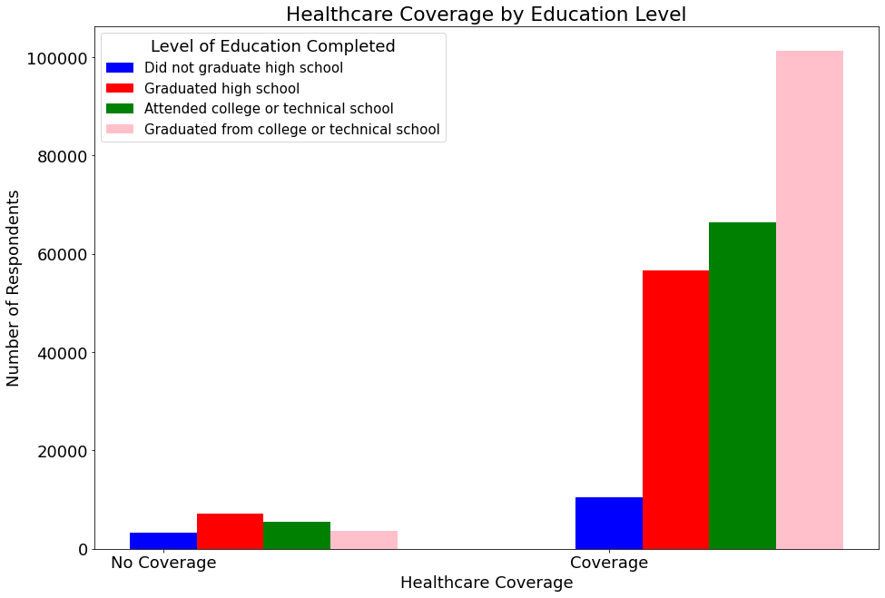

```python
# Loop through each of the four education levels and calculate how many respondents in each group are and are not covered by health insurance. The final list of these numbers should be of the form [[# without coverage, # with coverage]]
edu_vs_coverage = []

for i in range(1,5):
  no_coverage = len(survey_df.loc[(survey_df['Education'] == i) & (survey_df['Healthcare_Coverage'] == 2)])
  yes_coverage = len(survey_df.loc[(survey_df['Education'] == i) & (survey_df['Healthcare_Coverage'] == 1)])
  edu_vs_coverage.append([no_coverage, yes_coverage])

# Plot all 4 education levels in a bar chart to show how many respondents of each group are or are not covered
X = np.arange(2)
fig = plt.figure(figsize=(12, 8))
ax = fig.add_axes([0, 0, 1, 1])
ax.bar(X + 0.00, edu_vs_coverage[0], color = 'b', width = 0.15)
ax.bar(X + 0.15, edu_vs_coverage[1], color = 'r', width = 0.15)
ax.bar(X + 0.30, edu_vs_coverage[2], color = 'g', width = 0.15)
ax.bar(X + 0.45, edu_vs_coverage[3], color = 'pink', width = 0.15)

# Add a title, axis labels, and a legend
ax.set_ylabel('Number of Respondents')
ax.set_xlabel('Healthcare Coverage')
ax.set_title('Healthcare Coverage by Education Level')
ax.legend(prop={'size': 15}, title = 'Level of Education Completed', labels=['Did not graduate high school', 'Graduated high school', 'Attended college or technical school', 'Graduated from college or technical school'])

# Add labels to the two categories on the x axis
labels = ['No Coverage', 'Coverage']
ar = np.arange(len(labels))
ax.set_xticks(ar)
ax.set_xticklabels(labels)
```

From the above chart we can see that the highest education level has a larger differential between those who do and do not have healthcare coverage. Let's look at the percentage of coverage for each education level in order to compare the groups in a normalized manner:

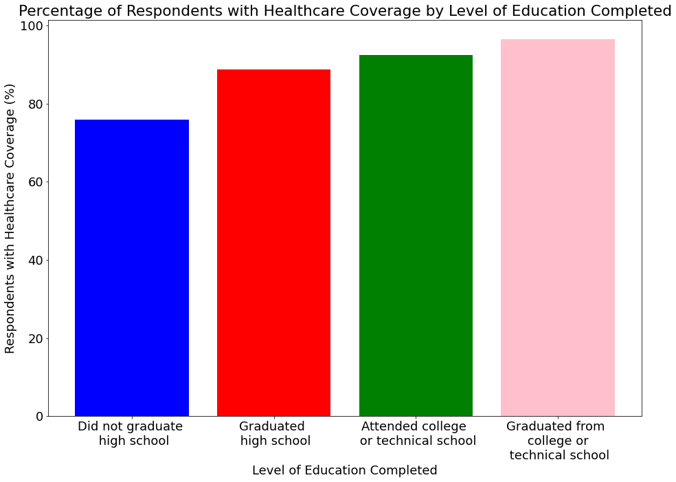

```python
# For each of the four education groups calculate what percentage of those respondents have healthcare coverage.
percentages = []
for i in range(0,4):
  covered = edu_vs_coverage[i][1]
  not_cov = edu_vs_coverage[i][0]
  tot = covered + not_cov
  perc = 100 * (covered/tot)
  percentages.append(perc)


# Plot the above percentages in a bar chart to show a proportional trend
fig = plt.figure(figsize=(12, 8))
ax = fig.add_axes([0,0,1,1])
edu_level = ['Did not graduate \n high school', 'Graduated \n high school', 'Attended college \n or technical school', 'Graduated from \n college or \n technical school']
# Pass a list of colors in order to keep color consistency with the above graph
ax.bar(edu_level, percentages, color = ['b', 'r', 'g', 'pink'])
ax.set_ylabel('Respondents with Healthcare Coverage (%)')
ax.set_xlabel('Level of Education Completed')
ax.set_title('Percentage of Respondents with Healthcare Coverage by Level of Education Completed')
plt.show()
```

### 5. Conclusion

In order to make a change to the US healthcare system, the focus must be on marginalized and lower class members of society. The basic human need of healthcare should be separated from classism and discrimination in order to best serve everyone in this country.